# A Quick Introduction to iNEXT.3D via Examples

Anne Chao

2023-07-27

```r
## install iNEXT.3D package from CRAN
# install.packages("iNEXT.3D")
## install the latest version from github
install.packages('devtools')
library(devtools)
# install_github('AnneChao/iNEXT.3D')
## import packages
library(iNEXT.3D)
library(ggplot2)
```

In this document, we provide a quick introduction demonstrating how to run the package `iNEXT.3D`(iNterpolation and EXTrapolation in three Dimensions). `iNEXT.3D` has several main function: `iNEXT3D`, `ggiNEXT3D`, `AO3D`, `ggAO3D`, `estimate3D`, and `DataInfo3D.`

`iNEXT3D` focuses on three measures of Hill numbers of order q: species richness (`q = 0`), Shannon diversity (`q = 1`, the exponential of Shannon entropy) and Simpson diversity (`q = 2`, the inverse of Simpson concentration) among three classes: taxonomic diversity (‘TD’), phylogenetic diversity (‘PD’), functional diversity (‘FD’). For each diversity measure, `iNEXT.3D` uses the observed sample of abundance or incidence data (called the “reference sample”) to compute diversity estimates and the associated confidence intervals for the following two types of rarefaction and extrapolation (R/E):

1. Sample‐size‐based R/E sampling curves:`iNEXT3D` computes diversity estimates for rarefied and extrapolated samples up to an appropriate size. This type of sampling curve plots the diversity estimates with respect to sample size.
2. Coverage‐based R/E sampling curves: `iNEXT3D` computes diversity estimates for rarefied and extrapolated samples with sample completeness (as measured by sample coverage) up to an appropriate coverage. This type of sampling curve plots the diversity estimates with respect to sample coverage.

`iNEXT3D` also plots the above two types of sampling curves and a sample completeness curve. The sample completeness curve provides a bridge between these two types of curves.

## MAIN FUNCTION: iNEXT3D()

We first describe the main function `iNEXT3D()` with default arguments:

```r
iNEXT3D(data, diversity = 'TD', q = c(0,1,2), datatype = "abundance",
        size = NULL, endpoint = NULL, knots = 40, nboot = 50, conf = 0.95, nT = NULL,
        PDtree = NULL, PDreftime = NULL, PDtype = 'meanPD',
        FDdistM, FDtype = 'AUC', FDtau = NULL)
```

The arguments of this function are briefly described below, and will be explained in more details by illustrative examples in later text. This main function computes diversity estimates of order q, the sample coverage estimates and related statistics for K (if `knots=K`) evenly‐spaced knots (sample sizes) between size 1 and the `endpoint`, where the endpoint is described below. Each knot represents a particular sample size for which diversity estimates will be calculated. By default, endpoint = double the reference sample size (total sample size for abundance data; total sampling units for incidence data). For example, if `endpoint = 10`, `knot = 4`, diversity estimates will be computed for a sequence of samples with sizes (1, 4, 7, 10).

Argument

Description

`data`

1. For datatype = “abundance”, data can be input as a vector of species abundances (for a single assemblage), matrix/data.frame (species by assemblages), or a list of species abundance vectors.
2. For datatype = “incidence_freq”, data can be input as a vector of incidence frequencies (for a single assemblage), matrix/data.frame (species by assemblages), or a list of incidence frequencies; the first entry in all types of input must be the number of sampling units in each assemblage.
3. For datatype = “incidence_raw”, data can be input as a list of matrix/data.frame (species by sampling units); data can also be input as a matrix/data.frame by merging all sampling units across assemblages based on species identity; in this case, the number of sampling units (nT, see below) must be input.

`diversity`

selection of diversity type: ‘TD’ = Taxonomic diversity, ‘PD’ = Phylogenetic diversity, and ‘FD’ = Functional diversity.

`q`

a numerical vector specifying the diversity orders. Default is c(0, 1, 2).

`datatype`

data type of input data: individual-based abundance data (datatype = “abundance”), sampling-unit-based incidence frequencies data (datatype = “incidence_freq”), or species by sampling-units incidence matrix (datatype = “incidence_raw”) with all entries being 0 (non-detection) or 1 (detection).

`size`

an integer vector of sample sizes (number of individuals or sampling units) for which diversity estimates will be computed. If NULL, then diversity estimates will be computed for those sample sizes determined by the specified/default endpoint and knots.

`endpoint`

an integer specifying the sample size that is the endpoint for rarefaction/extrapolation. If NULL, then endpoint = double reference sample size.

`knots`

an integer specifying the number of equally-spaced knots (say K, default is 40) between size 1 and the endpoint;each knot represents a particular sample size for which diversity estimate will be calculated. If the endpoint is smaller than the reference sample size, then iNEXT3D() computes only the rarefaction esimates for approximately K evenly spaced knots. If the endpoint is larger than the reference sample size, then iNEXT3D() computes rarefaction estimates for approximately K/2 evenly spaced knots between sample size 1 and the reference sample size, and computes extrapolation estimates for approximately K/2 evenly spaced knots between the reference sample size and the endpoint.

`nboot`

a positive integer specifying the number of bootstrap replications when assessing sampling uncertainty and constructing confidence intervals. Enter 0 to skip the bootstrap procedures. Default is 50.

`conf`

a positive number < 1 specifying the level of confidence interval. Default is 0.95.

`nT`

(required only when datatype = “incidence_raw” and input data is matrix/data.frame) a vector of nonnegative integers specifying the number of sampling units in each assemblage. If assemblage names are not specified, then assemblages are automatically named as “assemblage1”, “assemblage2”,…, etc.

`PDtree`

(required only when diversity = “PD”), a phylogenetic tree in Newick format for all observed species in the pooled assemblage.

`PDreftime`

(required only when diversity = “PD”), a vector of numerical values specifying reference times for PD. Default is NULL (i.e., the age of the root of PDtree).

`FDdistM`

(required only when diversity = “FD”), a species pairwise distance matrix for all species in the pooled assemblage.

`FDtype`

(required only when diversity = “FD”), select FD type: FDtype = “tau_values” for FD under specified threshold values, or FDtype = “AUC” (area under the curve of tau-profile) for an overall FD which integrates all threshold values between zero and one. Default is “AUC”.

`FDtau`

(required only when diversity = “FD” and FDtype = “tau_values”), a numerical vector between 0 and 1 specifying tau values (threshold levels). If NULL (default), then threshold is set to be the mean distance between any two individuals randomly selected from the pooled assemblage (i.e., quadratic entropy).

## DATA FORMAT/INFORMATION

Three types of data are supported:

1. Individual‐based abundance data (`datatype="abundance"`): Input data for each assemblage/site include samples species abundances in an empirical sample of n individuals (“reference sample”). When there are N assemblages, input data consist of an S by N abundance matrix, or N lists of species abundances.
2. Sampling‐unit‐based incidence data: There are two kinds of input data.
1. Incidence‐raw data (`datatype="incidence_raw"`): for each assemblage, input data for a reference sample consist of a species‐by‐sampling‐unit matrix; when there are N assemblages, input data consist of N lists of matrices, and each matrix is a species‐by‐sampling‐unit matrix. If the phylogenetic diversity required, the matrix of combined assemblage is allowed, but nT must be specified (see above description)..
2. Incidence‐frequency data (`datatype="incidence_freq"`): input data for each assemblage consist of species sample incidence frequencies (row sums of each incidence matrix). When there are N assemblages, input data consist of an S by N matrix, or N lists of species incidence frequencies. The first entry of each list must be the total number of sampling units, followed by the species incidence frequencies.

## RAREFACTION/EXTRAPOLATION VIA EXAMPLES

If one diversity class required, then `iNEXT3D()` function returns including: `$Info` for summarizing data information; `$iNextEst` for showing diversity estimates along with related statistics for a series of rarefied and extrapolated samples; and `$AsyEst` for showing asymptotic diversity estimates along with related statistics, otherwise, returns lists which length equal to the number of diversity class required and also named by diversity class. Among each list include three data frames:`$Info`, `$iNextEst` and `$AsyEst`.

`$Info`, as shown below, returns basic data information. It can also be presented using function `DataInfo()` (for “TD”), `PDInfo()` (for “PD”) and `AUCInfo()` (for “FD”).

```r
data("dunes")
str(dunes$data)
iNEXT3D(dunes$data, diversity = "TD", q = c(0, 1, 2), datatype = "abundance")
```

```
$DataInfo: Taxonomic basic data information
Assemblage  n   S.obs   SC     f1    f2    f3    f4    f5    f6    f7    f8    f9   f10

1 EM      373    17   0.992     3     1     1     0     0     1     0     1     1     1
2 MO      1490   39   0.999     2     1     1     4     2     2     3     1     1     1
3 TR      1059   42   0.996     4     2     4     2     2     2     0     1     2     2
```

```r
data("dunes")
str(dunes$data)
iNEXT3D(dunes$data, diversity = "PD", q = c(0, 1, 2), datatype = "abundance", PDtree = dunes$tree)
```

```
$PDInfo: phylogenetic basic data information
Assemblage     n    S.obs PD.obs `f1*` `f2*`    g1    g2    Reftime
1 EM           373    17  2660.   3     1     309     65       325
2 MO          1490    39  4783.   2     1     211     43.3     325
3 TR          1059    42  5303.   4     2     352     108      325
```

```r
data("dunes")
str(dunes$data)
iNEXT3D(dunes$data, diversity = "FD", q = c(0, 1, 2), datatype = "abundance", FDdistM = dunes$dist)
```

```
$AUCInfo: functional basic data information
  Assemblage  n   S.obs   SC     f1    f2    f3    f4    f5    f6    f7    f8    f9   f10
1 EM      373    17   0.992     3     1     1     0     0     1     0     1     1     1
2 MO      1490   39   0.999     2     1     1     4     2     2     3     1     1     1
3 TR      1059   42   0.996     4     2     4     2     2     2     0     1     2     2
```

For the sample size corresponding to each knot, the first data frame of list `$iNextEst` (as shown below for ‘size_based’) under each diversity class includes the sample size (`m`, i.e., each of the 40 knots), the method (`interpolated`, `observed`, or `extrapolated`, depending on whether the size `m` is less than, equal to, or greater than the reference sample size), the diversity order, the diversity estimate of order q (`qD`, `qPD`, `qFD` and `qAUC`), the 95% lower and upper confidence limits of diversity (`qD.LCL` with`qD.UCL`, `qPD.LCL` with `qPD.UCL`, `qFD.LCL` with `qFD.UCL` and `qAUC.LCL` with `qAUC.UCL`), and the sample coverage estimate (`SC`) along with the 95% lower and upper confidence limits of sample coverage (`SC.LCL`, `SC.UCL`). These sample coverage estimates with confidence intervals are used for plotting the sample completeness curve. Time consuming for `class = "AUC"`, therefore the demo shows only first three class.

```r
head(out.TD$iNextEst$size_based)
# A tibble: 6 x 10
  Assemblage     m Method      Order.q    qD qD.LCL qD.UCL    SC SC.LCL SC.UCL
  <chr>      <dbl> <chr>         <dbl> <dbl>  <dbl>  <dbl> <dbl>  <dbl>  <dbl>
1 EM             1 Rarefaction       0  1      1.00   1    0.136  0.124  0.149
2 EM            20 Rarefaction       0  8.22   7.79   8.65 0.837  0.818  0.855
3 EM            40 Rarefaction       0 10.6    9.92  11.2  0.915  0.902  0.929
4 EM            59 Rarefaction       0 11.9   11.1   12.7  0.945  0.931  0.959
5 EM            79 Rarefaction       0 12.8   11.8   13.8  0.962  0.949  0.975
6 EM            98 Rarefaction       0 13.4   12.3   14.6  0.972  0.961  0.983
head(out.PD$PDiNextEst$size_based)
# A tibble: 6 x 12
  Assemblage     m Method      Order.q   qPD qPD.LCL qPD.UCL    SC SC.LCL SC.UCL Reftime Type
  <chr>      <dbl> <chr>         <dbl> <dbl>   <dbl>   <dbl> <dbl>  <dbl>  <dbl>   <dbl> <chr>
1 EM             1 Rarefaction       0  1      0.955    1.04 0.136  0.122  0.151     325 meanPD
2 EM            20 Rarefaction       0  5.00   4.73     5.27 0.837  0.817  0.856     325 meanPD
3 EM            40 Rarefaction       0  5.93   5.55     6.30 0.915  0.899  0.931     325 meanPD
4 EM            59 Rarefaction       0  6.41   5.97     6.86 0.945  0.929  0.960     325 meanPD
5 EM            79 Rarefaction       0  6.75   6.23     7.26 0.962  0.948  0.976     325 meanPD
6 EM            98 Rarefaction       0  6.98   6.39     7.56 0.972  0.959  0.984     325 meanPD
head(out.FD$AUCiNextEst$size_based)
# A tibble: 6 x 10
  Assemblage     m Method      Order.q  qAUC qAUC.LCL qAUC.UCL    SC SC.LCL SC.UCL
  <chr>      <dbl> <chr>         <dbl> <dbl>    <dbl>    <dbl> <dbl>  <dbl>  <dbl>
1 EM             1 Rarefaction       0  1        1        1    0.136  0.126  0.147
2 EM            20 Rarefaction       0  5.86     5.45     6.27 0.837  0.804  0.869
3 EM            40 Rarefaction       0  7.03     6.33     7.73 0.915  0.891  0.939
4 EM            59 Rarefaction       0  7.65     6.79     8.51 0.945  0.926  0.963
5 EM            79 Rarefaction       0  8.08     7.10     9.06 0.962  0.948  0.976
6 EM            98 Rarefaction       0  8.36     7.30     9.43 0.972  0.961  0.983
```

```r
head(out.TD$iNextEst$coverage_based)
# A tibble: 6 x 8
  Assemblage    SC     m Method      Order.q    qD qD.LCL qD.UCL
  <chr>      <dbl> <dbl> <chr>         <dbl> <dbl>  <dbl>  <dbl>
1 EM         0.136   1   Rarefaction       0  1     0.971   1.03
2 EM         0.837  20.0 Rarefaction       0  8.22  7.40    9.04
3 EM         0.915  40.0 Rarefaction       0 10.6   9.51   11.7
4 EM         0.945  59.0 Rarefaction       0 11.9  10.5    13.3
5 EM         0.962  79.0 Rarefaction       0 12.8  11.1    14.6
6 EM         0.972  98.0 Rarefaction       0 13.4  11.5    15.4
head(out.PD$PDiNextEst$coverage_based)
# A tibble: 6 x 10
  Assemblage    SC     m Method      Order.q   qPD qPD.LCL qPD.UCL Reftime Type
  <chr>      <dbl> <dbl> <chr>         <dbl> <dbl>   <dbl>   <dbl>   <dbl> <chr>
1 EM         0.136     1 Rarefaction       0  1      0.955    1.04     325 meanPD
2 EM         0.837    20 Rarefaction       0  5.00   4.59     5.41     325 meanPD
3 EM         0.915    40 Rarefaction       0  5.93   5.39     6.47     325 meanPD
4 EM         0.945    59 Rarefaction       0  6.41   5.75     7.08     325 meanPD
5 EM         0.962    79 Rarefaction       0  6.75   5.96     7.54     325 meanPD
6 EM         0.972    98 Rarefaction       0  6.98   6.06     7.90     325 meanPD
head(out.FD$AUCiNextEst$coverage_based)
# A tibble: 6 x 8
  Assemblage    SC     m Method      Order.q  qAUC qAUC.LCL qAUC.UCL
  <chr>      <dbl> <dbl> <chr>         <dbl> <dbl>    <dbl>    <dbl>
1 EM         0.136   1   Rarefaction       0  1       0.953     1.05
2 EM         0.837  20.0 Rarefaction       0  5.86    5.16      6.56
3 EM         0.915  40.0 Rarefaction       0  7.03    6.09      7.97
4 EM         0.945  59.0 Rarefaction       0  7.65    6.61      8.69
5 EM         0.962  79.0 Rarefaction       0  8.08    6.94      9.22
6 EM         0.972  98.0 Rarefaction       0  8.36    7.11      9.62
```

`$AsyEst` lists the observed diversity, asymptotic estimates, estimated bootstrap s.e. and 95% confidence intervals for Hill numbers with q = 0, 1, and 2. The estimated asymptotes and the observed diversity are calculated via the functions `AO3D()` . The output for the dunes data is shown below. All row and column variables are self‐explanatory.

```r
out.TD$AsyEst
  Assemblage         Diversity  Observed Estimator      s.e.       LCL       UCL
1         EM  Species richness 17.000000 21.487936 5.3320231 17.000000 31.938509
2         EM Shannon diversity  9.272102  9.541765 0.2303751  9.090238  9.993292
3         EM Simpson diversity  7.218106  7.340810 0.1682732  7.011001  7.670620
4         MO  Species richness 39.000000 40.998658 4.9257711 39.000000 50.652992
5         MO Shannon diversity 19.712107 19.987465 0.3852090 19.232470 20.742461
6         MO Simpson diversity 13.979950 14.102888 0.4158537 13.287830 14.917947
7         TR  Species richness 42.000000 45.996223 8.6905350 42.000000 63.029358
8         TR Shannon diversity 23.941938 24.481173 0.4739251 23.552297 25.410050
9         TR Simpson diversity 18.605455 18.920295 0.5784598 17.786534 20.054055
```

```r
out.PD$PDAsyEst
  Assemblage Phylogenetic Diversity Phylogenetic Observed Phylogenetic Estimator       s.e.       LCL       UCL Reftime   Type
1         EM               q = 0 PD              8.183333              10.433534 2.39379475  8.183333 15.125286     325 meanPD
2         EM               q = 1 PD              4.129275               4.178872 0.09874252  3.985340  4.372403     325 meanPD
3         EM               q = 2 PD              2.844695               2.858872 0.09282620  2.676936  3.040808     325 meanPD
4         MO               q = 0 PD             14.716667              14.879058 2.06180776 14.716667 18.920127     325 meanPD
5         MO               q = 1 PD              5.097006               5.122369 0.06461763  4.995720  5.249017     325 meanPD
6         MO               q = 2 PD              3.035178               3.039333 0.04099478  2.958984  3.119681     325 meanPD
7         TR               q = 0 PD             16.316667              18.075421 1.85468842 16.316667 21.710543     325 meanPD
8         TR               q = 1 PD              5.899315               5.946866 0.09697753  5.756793  6.136938     325 meanPD
9         TR               q = 2 PD              3.255497               3.262452 0.05231301  3.159921  3.364984     325 meanPD
```

```r
out.FD$AUCAsyEst
  Assemblage Functional Diversity Functional Observed Functional Estimator      s.e.       LCL       UCL
1         EM        q = 0 FD(AUC)            9.695652            10.547035 1.0259845  9.695652 12.557927
2         EM        q = 1 FD(AUC)            6.215286             6.324249 0.1893733  5.953084  6.695414
3         EM        q = 2 FD(AUC)            5.223172             5.293984 0.1839909  4.933369  5.654600
4         MO        q = 0 FD(AUC)           19.672589            20.290241 0.8034691 19.672589 21.865011
5         MO        q = 1 FD(AUC)           11.921050            12.034159 0.2253303 11.592520 12.475798
6         MO        q = 2 FD(AUC)            9.502779             9.570843 0.2047955  9.169451  9.972235
7         TR        q = 0 FD(AUC)           20.928778            21.833483 0.4718563 20.928778 22.758304
8         TR        q = 1 FD(AUC)           13.500793            13.706689 0.2051594 13.304584 14.108794
9         TR        q = 2 FD(AUC)           11.170237            11.316038 0.2248921 10.875258 11.756818
```

The user may specify an integer sample size for the argument endpoint to designate the maximum sample size of R/E calculation. For species richness, the extrapolation method is reliable up to the double reference sample size; beyond that, the prediction bias may be large. However, for measures of q = 1 and 2, the extrapolation can usually be safely extended to the asymptotic if data are not sparse; thus there is no limit for the value of endpoint for these two measures.

The user may also specify the number of knots in the range of sample size between 1 and the endpoint. If you choose a large number of knots, then it may take a long time to obtain the output due to the time‐consuming bootstrap method. Alternatively, the user may specify a series of sample sizes for R/E computation, as in the following example:

```r
# set a series of sample sizes (m) for R/E computation
m <- c(1, 5, 20, 50, 100, 200, 400)
iNEXT3D(dunes$data, diversity = "TD",
       q = 0, datatype="abundance", size = m)
```

Further, `iNEXT3D` can simultaneously run R/E computation for Hill numbers with q = 0, 1, and 2 by specifying a vector for the argument `q` as follows:

```r
iNEXT3D(dunes$data, diversity = "TD",
        q = c(0,1,2), datatype = "abundance", size = m)
```

## GRAPHIC DISPLAYS: FUNCTION ggiNEXT3D()

The function `ggiNEXT3D()`, which extends `ggplot2` with default arguments, is described as follows:

```r
ggiNEXT3D(outcome, type = 1:3, se = TRUE,
          facet.var = "Assemblage", color.var = "Order.q")
```

Here `outcome` is the object of `iNEXT3D()`’s output. Three types of curves are allowed for different diversity classes:

The argument `facet.var="Assemblage"` in `ggiNEXT3D` function creates a separate plot for each assembalge, therefore the different Order.q will seperated by different colours as shown below:

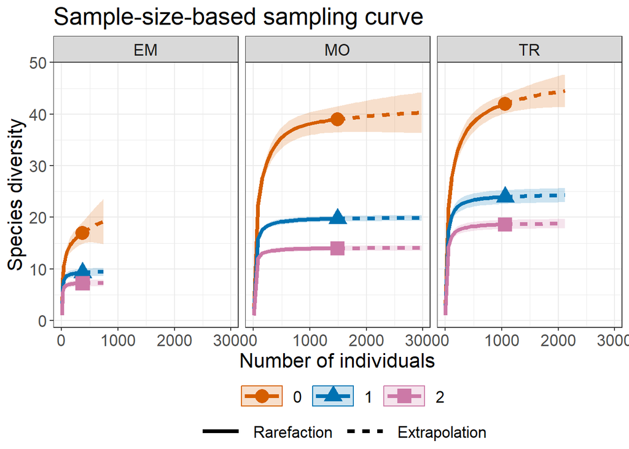

```r
# Sample‐size‐based R/E curves, separating by "assemblage""
ggiNEXT3D(out.TD, type = 1, facet.var = "Assemblage")
```

The argument `facet.var="Order.q"` in `ggiNEXT3D` function creates a separate plot for each order, therefore three assemblages will be seperated by different colours as shown below:

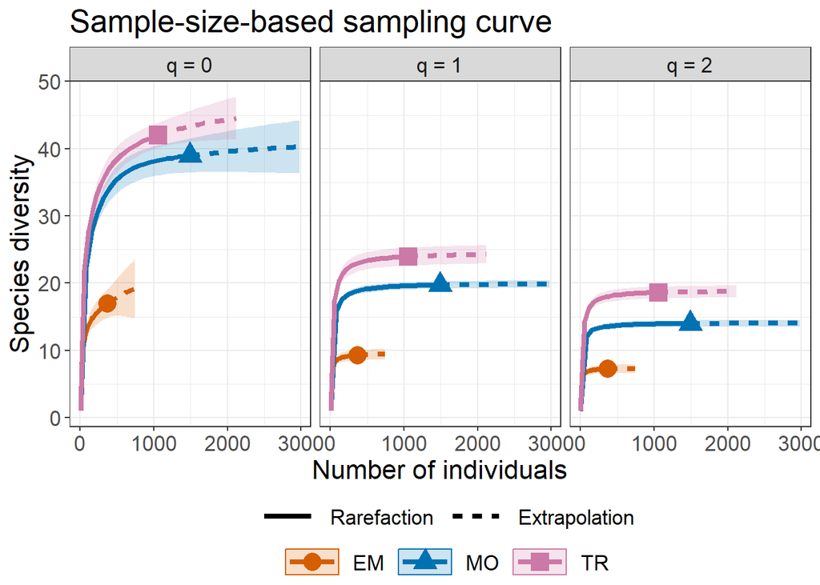

```r
# Sample‐size‐based R/E curves, separating by "Order.q"
ggiNEXT3D(out.TD, type = 1, facet.var = "Order.q")
```

The following commands return the sample completeness curve in which different colors are used for the three assemblages. Since the sample completeness curve are same for differnet class of diversity, `ggiNEXT3D` returns only one plot:

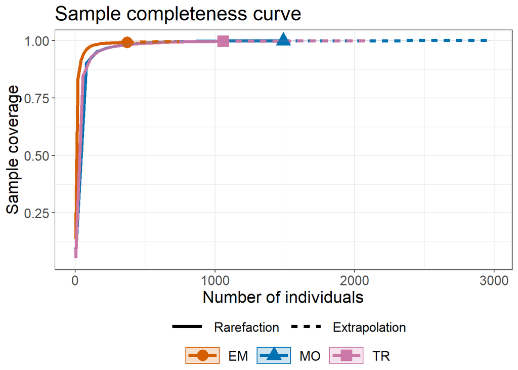

```r
ggiNEXT3D(out.TD, type = 2, facet.var = "Order.q", color.var="Assemblage")
```

The following commands return the coverage‐based R/E sampling curves in which different colors are used for the three assemblages (`facet.var="Assemblage"`) and for three orders (`facet.var="Order.q"`)

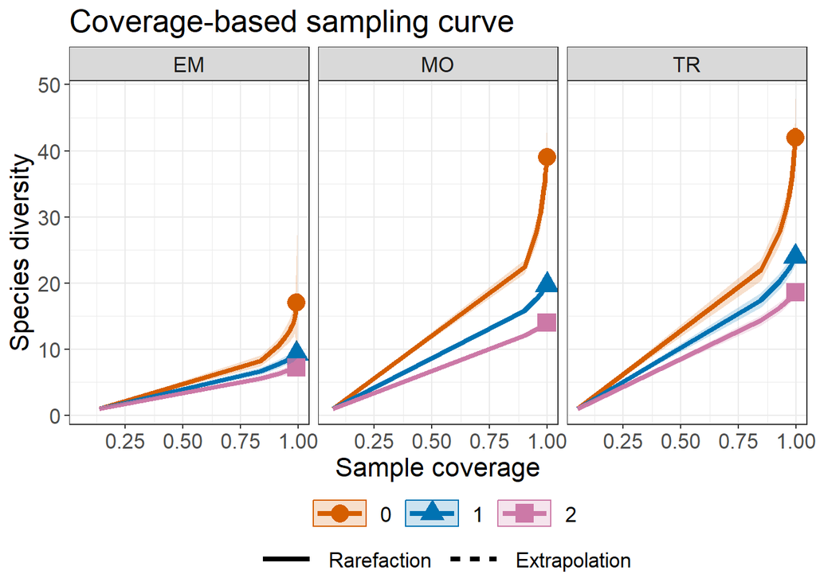

```r
ggiNEXT3D(out.TD, type = 3, facet.var="Assemblage")
```

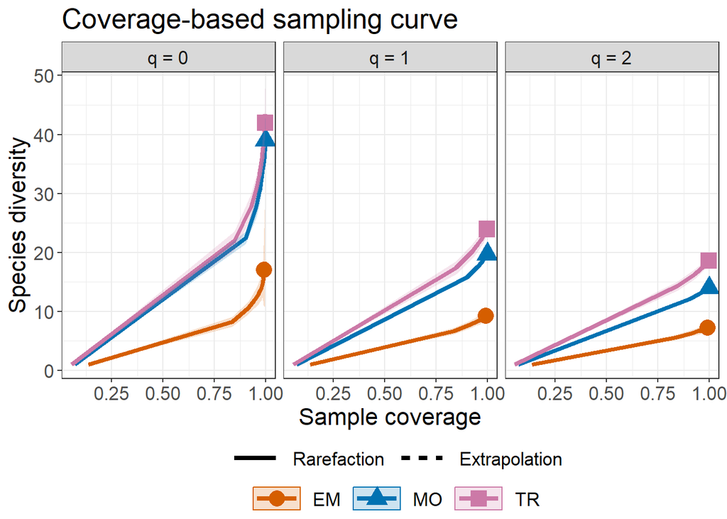

```r
ggiNEXT3D(out.TD, type = 3, facet.var="Order.q")
```

## RAW INCIDENCE DATA FUNCTION: incidence_raw

For illustration, we use the Hinkley’s fish data (in the dataset fish included in the package) at three time periods (1981-1985, 1987-1991 and 2015-2019). Incidence raw data is allowed for all diversity class.This data set (`fish`) included in the package is three list of matrices; each matrix is a species by plots data.frame for a time period. We only use Taxonomic diversity(TD) for demonstration below.

```r
data("fish")
head(fish[[1]]$`1981-1985`,4)
                    1 2 3 4 5 6 7 8 9 10 11 12 13 14 15 17 18 19 20 21 22 23 24 25 26 27 28 29 30 31 32 33 34 35 36 37 38 39 40 41 42 43 44 45 46 47 48 49 50 51 52 53 54 55 56 57 58 59 60 61
Agonus_cataphractus 0 0 1 0 0 0 0 0 0  0  0  0  0  0  0  0  0  0  0  0  1  1  0  0  1  0  1  1  1  0  0  0  0  1  0  0  0  0  0  0  0  0  0  0  0  1  0  1  0  0  1  0  1  0  0  0  0  1  1  0
Alosa_fallax        0 0 0 0 0 0 0 0 1  0  0  0  1  0  0  0  0  0  1  1  0  1  0  1  1  0  1  0  0  1  1  1  1  1  1  0  1  0  0  1  1  1  0  1  1  1  1  1  0  0  1  1  1  1  1  0  0  0  0  1
Ammodytes_marinus   0 0 0 0 0 0 0 0 0  0  0  0  0  0  0  0  0  0  0  0  0  0  0  0  0  0  0  0  0  0  0  0  0  0  0  0  0  0  0  0  0  0  0  0  0  0  0  0  0  0  0  0  0  0  0  0  0  0  0  0
Ammodytes_tobianus  0 0 0 0 0 0 1 0 0  0  0  1  0  0  0  0  0  0  0  0  0  0  0  0  0  0  0  0  0  0  0  0  0  1  0  0  0  0  0  0  0  0  0  1  0  0  0  0  0  0  0  0  0  0  0  0  0  0  0  0
```

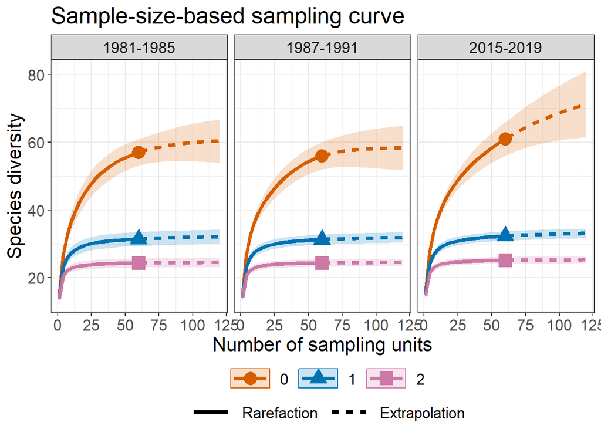

```r
# fish.tree = fish$tree
# fish.dis = fish$dist

out.raw <- iNEXT3D(data = fish$data,
                   diversity = "TD",
                   q = c(0, 1, 2), datatype = "incidence_raw",nboot = 10)
ggiNEXT3D(out.raw, type = 1)
```

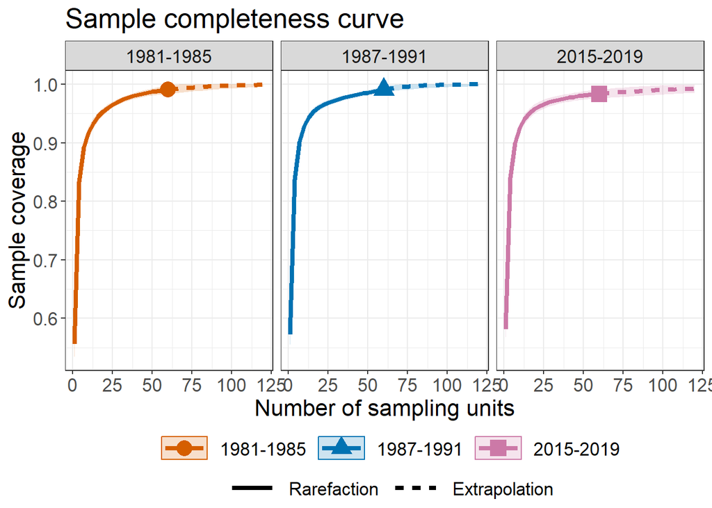

```r
ggiNEXT3D(out.raw, type = 2)
```

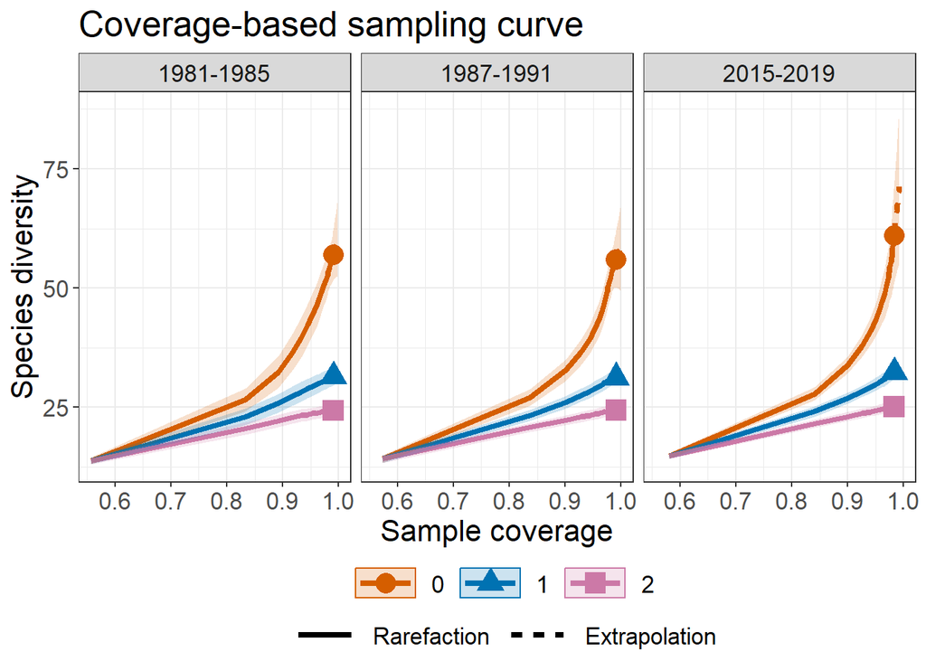

```r
ggiNEXT3D(out.raw, type = 3)
```

## FREQUENCIES INCIDENCE DATA FUNCTION: incidence_freq

We transform Hinkley’s fish data(incidence raw data) to incidence freqencies data(incidence_freq). Data.frame of first list consist of incidence frequencies are shown below. The first row must be the total number of sampling units, followed by the species incidence frequencies. We only use Taxonomic diversity(TD) for demonstration below.

```r
fish.freq = cbind(c(ncol(fish$data$`1981-1985`),rowSums(fish$data$`1981-1985`)),
                  c(ncol(fish$data$`1987-1991`),rowSums(fish$data$`1987-1991`)),
                  c(ncol(fish$data$`2015-2019`),rowSums(fish$data$`2015-2019`)))
rownames(fish.freq)[1]="sample units"
colnames(fish.freq)=names(fish$data)
```

```r
head(fish.freq)
                    1981-1985 1987-1991 2015-2019
sample units               60        60        60
Agonus_cataphractus        14        19        21
Alosa_fallax               29        22        18
Ammodytes_marinus           0         0         0
Ammodytes_tobianus          4         2         8
Anguilla_anguilla          30        29         8
```

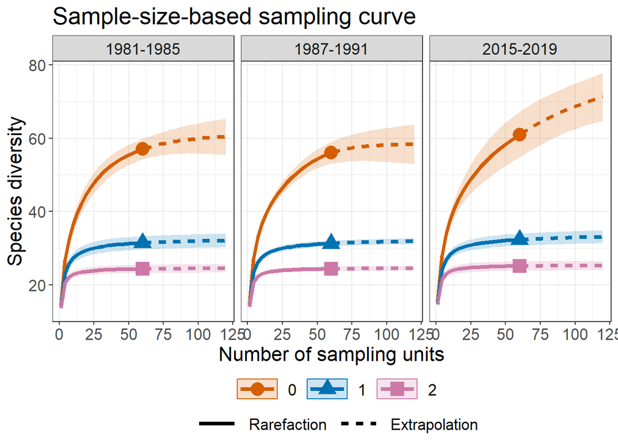

```r
out.incfreq <- iNEXT3D(data = fish.freq,
                   diversity = "TD",
                   q = c(0,1,2), datatype = "incidence_freq",nboot = 10)


# Sample‐size‐based R/E curves
ggiNEXT3D(out.incfreq, type = 1, color.var = "Assemblage")
```

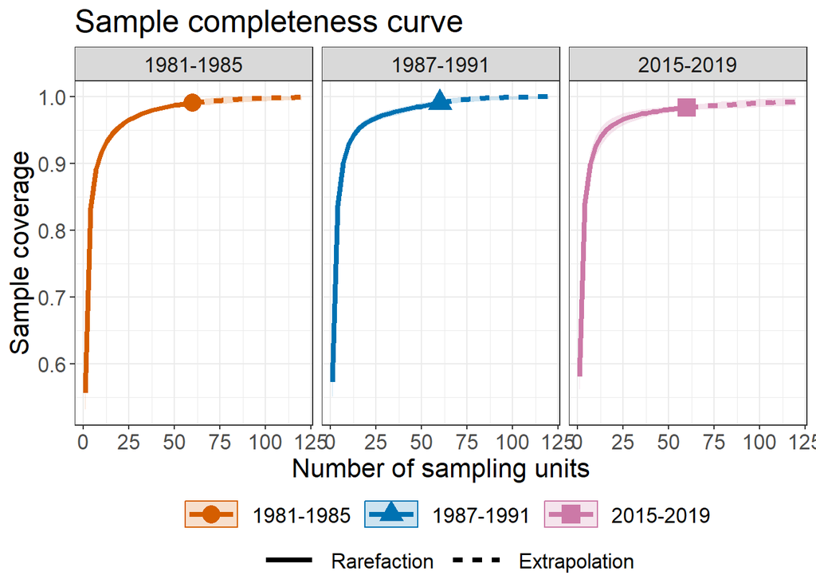

```r
# Sample completeness curves
ggiNEXT3D(out.incfreq, type = 2, color.var = "Assemblage")
```

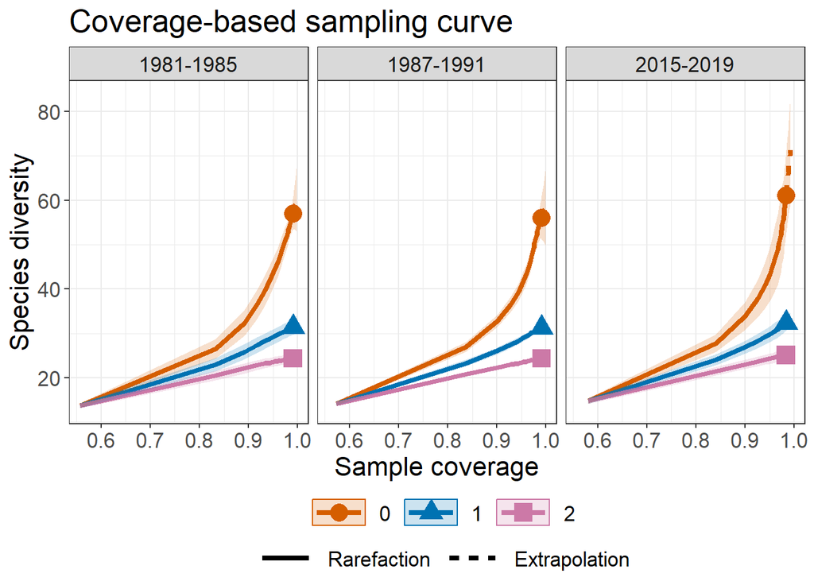

```r
# Coverage‐based R/E curves
ggiNEXT3D(out.incfreq, type = 3, color.var = "Assemblage")
```

## DATA INFORMATION FUNCTION: DataInfo3D()

We can supply the function

```r
DataInfo3D(data, diversity = "TD", datatype = "abundance",
  nT = NULL, PDtree, PDreftime = NULL,
  FDdistM, FDtype = "AUC", FDtau = NULL)
```

to compute three type diversity(‘TD’,‘PD’,‘FD’) data information, which including sample size, observed species richness, sample coverage estimate, and the first ten abundance/incidence frequency counts, and so on.

```r
DataInfo3D(dunes$data, diversity = 'TD', datatype = "abundance")
  Assemblage    n S.obs     SC f1 f2 f3 f4 f5 f6 f7 f8 f9 f10
1         EM  373    17 0.9920  3  1  1  0  0  1  0  1  1   1
2         MO 1490    39 0.9987  2  1  1  4  2  2  3  1  1   1
3         TR 1059    42 0.9962  4  2  4  2  2  2  0  1  2   2
```

## POINT ESTIMATION FUNCTION: estimate3D()

We also supply the function

```r
estimate3D(data, diversity = "TD", q = c(0, 1, 2), datatype = "abundance",
  base = "coverage", level = NULL, nboot = 50, conf = 0.95,
  nT = NULL, PDtree, PDreftime = NULL, PDtype = "meanPD",
  FDdistM, FDtype = "AUC", FDtau = NULL)
```

to compute three type diversity(‘TD’,‘PD’,‘FD’) estimates with q = 0, 1, 2 for any particular level of sample size (`base="size"`) or any specified level of sample coverage (`base="coverage"`) for either abundance data (`datatype="abundance"`) or incidence data (`datatype="incidence_freq" or "incidence_raw"`). If `level=NULL`, this function computes the diversity estimates for the minimum sample size/coverage among all assemblages.

```r
estimate3D(dunes$data, diversity = 'TD', q = c(0,1,2), datatype = "abundance", base = "coverage",level = 0.93)
  Assemblage   SC         m      Method Order.q        qD      s.e.    qD.LCL    qD.UCL
1         EM 0.93  47.88966 Rarefaction       0 11.194508 0.6416340  9.936928 12.452087
2         EM 0.93  47.88966 Rarefaction       1  8.004329 0.4283345  7.164809  8.843849
3         EM 0.93  47.88966 Rarefaction       2  6.482469 0.3718733  5.753611  7.211327
4         MO 0.93 107.56810 Rarefaction       0 24.830302 0.7264024 23.406580 26.254025
5         MO 0.93 107.56810 Rarefaction       1 16.735683 0.5038793 15.748097 17.723268
6         MO 0.93 107.56810 Rarefaction       2 12.571520 0.4455242 11.698309 13.444732
7         TR 0.93 114.37603 Rarefaction       0 27.935556 0.9206582 26.131099 29.740013
8         TR 0.93 114.37603 Rarefaction       1 20.360646 0.5795046 19.224838 21.496454
9         TR 0.93 114.37603 Rarefaction       2 16.357398 0.4900566 15.396905 17.317891
```

## EMPIRICAL AND ASYMPTOTIC DIVERSITY FUNCTION: AO3D

```r
AO3D(
  data,diversity = "TD",q = seq(0,2,0.2),datatype = "abundance",
  nboot = 50,conf = 0.95,nT = NULL,method = c("Asymptotic", "Observed"),
  PDtree,PDreftime = NULL,PDtype = "meanPD",
  FDdistM,FDtype = "AUC",FDtau = NULL
)
```

The function `AO3D()` can compute three type diversity(‘TD’,‘PD’,‘FD’),which including empirical diversity and asymptotic diversity. For either abundance data (`datatype="abundance"`) or incidence data(`datatype="incidence_freq" or "incidence_raw"`)with any specified level of q can be compute.

For example, the following command returns an empirical taxonomic diversity(‘TD’) and asymptotic taxonomic diversity(‘TD’) for dunes data, along with its confidence interval, for a specified q level from 0 to 2.

```r
out1 <- AO3D(dunes$data, diversity = 'TD', datatype = "abundance", method = c("Asymptotic", "Observed"),nboot = 5,conf = 0.95)

out1
   Order.q        qD      s.e.    qD.LCL    qD.UCL Assemblage     Method
1      0.0 21.487936 8.4460496  4.933983 38.041889         EM Asymptotic
2      0.2 16.936433 4.6422346  7.837820 26.035046         EM Asymptotic
3      0.4 13.885407 2.4806360  9.023449 18.747364         EM Asymptotic
4      0.6 11.862781 1.3808237  9.156416 14.569146         EM Asymptotic
5      0.8 10.496859 0.8454629  8.839783 12.153936         EM Asymptotic
6      1.0  9.541765 0.5756746  8.413463 10.670067         EM Asymptotic
7      1.2  8.847719 0.4279866  8.008880  9.686557         EM Asymptotic
8      1.4  8.325449 0.3408083  7.657477  8.993421         EM Asymptotic
9      1.6  7.920890 0.2871092  7.358166  8.483614         EM Asymptotic
10     1.8  7.600095 0.2535093  7.103226  8.096964         EM Asymptotic
11     2.0  7.340810 0.2324856  6.885147  7.796474         EM Asymptotic
12     0.0 40.998658 2.3989769 36.296749 45.700566         MO Asymptotic
13     0.2 34.209437 1.5959537 31.081425 37.337449         MO Asymptotic
14     0.4 29.060182 1.1559878 26.794487 31.325876         MO Asymptotic
15     0.6 25.175831 0.9112945 23.389727 26.961936         MO Asymptotic
16     0.8 22.235885 0.7749687 20.716974 23.754796         MO Asymptotic
17     1.0 19.987465 0.7045012 18.606668 21.368262         MO Asymptotic
18     1.2 18.241913 0.6742947 16.920320 19.563507         MO Asymptotic
19     1.4 16.863382 0.6665826 15.556904 18.169859         MO Asymptotic
20     1.6 15.755819 0.6697101 14.443211 17.068426         MO Asymptotic
21     1.8 14.851614 0.6768729 13.524968 16.178261         MO Asymptotic
22     2.0 14.102888 0.6845197 12.761254 15.444522         MO Asymptotic
23     0.0 45.996223 5.8291642 34.571271 57.421175         TR Asymptotic
24     0.2 38.731480 2.9196570 33.009057 44.453902         TR Asymptotic
25     0.4 33.399637 1.3785839 30.697663 36.101612         TR Asymptotic
26     0.6 29.505773 0.6976176 28.138468 30.873078         TR Asymptotic
27     0.8 26.635682 0.5427905 25.571832 27.699532         TR Asymptotic
28     1.0 24.481173 0.5855625 23.333492 25.628855         TR Asymptotic
29     1.2 22.827199 0.6475948 21.557936 24.096461         TR Asymptotic
30     1.4 21.527891 0.6973524 20.161106 22.894677         TR Asymptotic
31     1.6 20.484834 0.7355909 19.043102 21.926565         TR Asymptotic
32     1.8 19.631065 0.7658631 18.130000 21.132129         TR Asymptotic
33     2.0 18.920295 0.7906669 17.370616 20.469973         TR Asymptotic
34     0.0 17.000000 1.3416408 14.370432 19.629568         EM  Empirical
35     0.2 14.471457 0.9143801 12.679305 16.263609         EM  Empirical
36     0.4 12.567736 0.6450499 11.303461 13.832010         EM  Empirical
37     0.6 11.145510 0.4978996 10.169644 12.121375         EM  Empirical
38     0.8 10.079552 0.4293471  9.238047 10.921057         EM  Empirical
39     1.0  9.272102 0.4014966  8.485183 10.059021         EM  Empirical
40     1.2  8.651511 0.3908922  7.885376  9.417645         EM  Empirical
41     1.4  8.166818 0.3864502  7.409390  8.924247         EM  Empirical
42     1.6  7.782094 0.3837485  7.029961  8.534227         EM  Empirical
43     1.8  7.471913 0.3812323  6.724712  8.219115         EM  Empirical
44     2.0  7.218106 0.3784551  6.476348  7.959865         EM  Empirical
45     0.0 39.000000 1.5165751 36.027567 41.972433         MO  Empirical
46     0.2 32.970780 0.9368399 31.134607 34.806952         MO  Empirical
47     0.4 28.269000 0.6229556 27.048029 29.489970         MO  Empirical
48     0.6 24.647500 0.4699655 23.726384 25.568615         MO  Empirical
49     0.8 21.864493 0.4003023 21.079915 22.649071         MO  Empirical
50     1.0 19.712107 0.3674166 18.991984 20.432230         MO  Empirical
51     1.2 18.026804 0.3485447 17.343669 18.709939         MO  Empirical
52     1.4 16.686924 0.3340434 16.032211 17.341637         MO  Empirical
53     1.6 15.604656 0.3203219 14.976836 16.232475         MO  Empirical
54     1.8 14.717297 0.3063701 14.116823 15.317772         MO  Empirical
55     2.0 13.979950 0.2921831 13.407282 14.552619         MO  Empirical
56     0.0 42.000000 1.6431677 38.779451 45.220549         TR  Empirical
57     0.2 36.253363 1.3113438 33.683177 38.823550         TR  Empirical
58     0.4 31.844736 1.0629927 29.761308 33.928163         TR  Empirical
59     0.6 28.487492 0.8824319 26.757957 30.217026         TR  Empirical
60     0.8 25.922807 0.7531045 24.446750 27.398865         TR  Empirical
61     1.0 23.941938 0.6609219 22.646555 25.237321         TR  Empirical
62     1.2 22.387845 0.5955946 21.220500 23.555189         TR  Empirical
63     1.4 21.146894 0.5501554 20.068610 22.225179         TR  Empirical
64     1.6 20.138290 0.5198804 19.119343 21.157237         TR  Empirical
65     1.8 19.304760 0.5013698 18.322093 20.287427         TR  Empirical
66     2.0 18.605455 0.4919873 17.641177 19.569732         TR  Empirical
```

## GRAPHIC DISPLAYS FUNCTION: ggAO3D()

Plots q-profile, time-profile, and tau-profile based on the outcome of AO3D using the ggplot2 package.

The function `ggAO3D()`, which extends `ggplot2` with default arguments, is described as follows:

```r
ggAO3D(outcome, profile = "q")
```

Here `outcome` is the object of `AO3D`’s output and `profile` is an object versus to diversity.Default is `profile = "q"`.Note that `profile = "time"` is allowed for only when diversity = “PD” and `profile = "tau"` profile is allowed for only when `diversity = "FD"` and `FDtype = "tau_values"`.

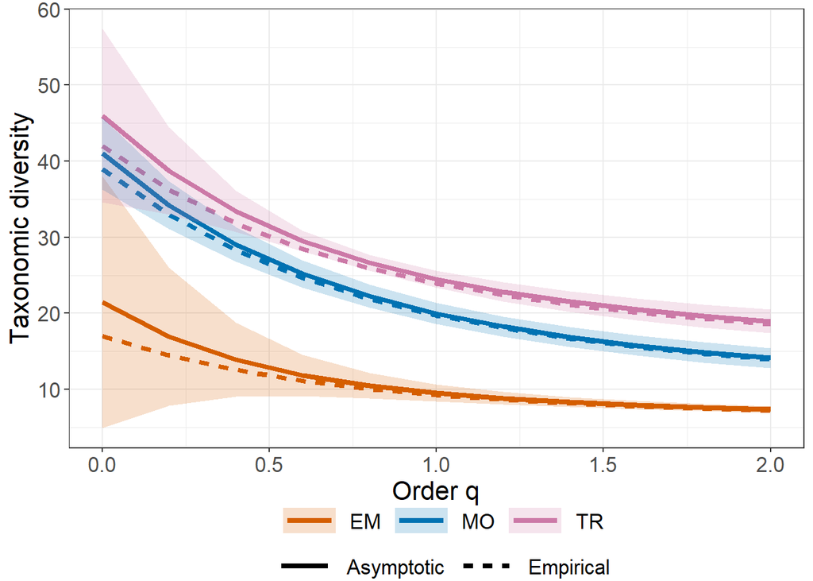

```r
# q profile curve""
ggAO3D(out1,profile = "q")
```

The argument `profile = "time"` in `ggAO3D` function creates a separate plot for each order.q. Therefore the different assemblages will seperated by different colours as shown below:

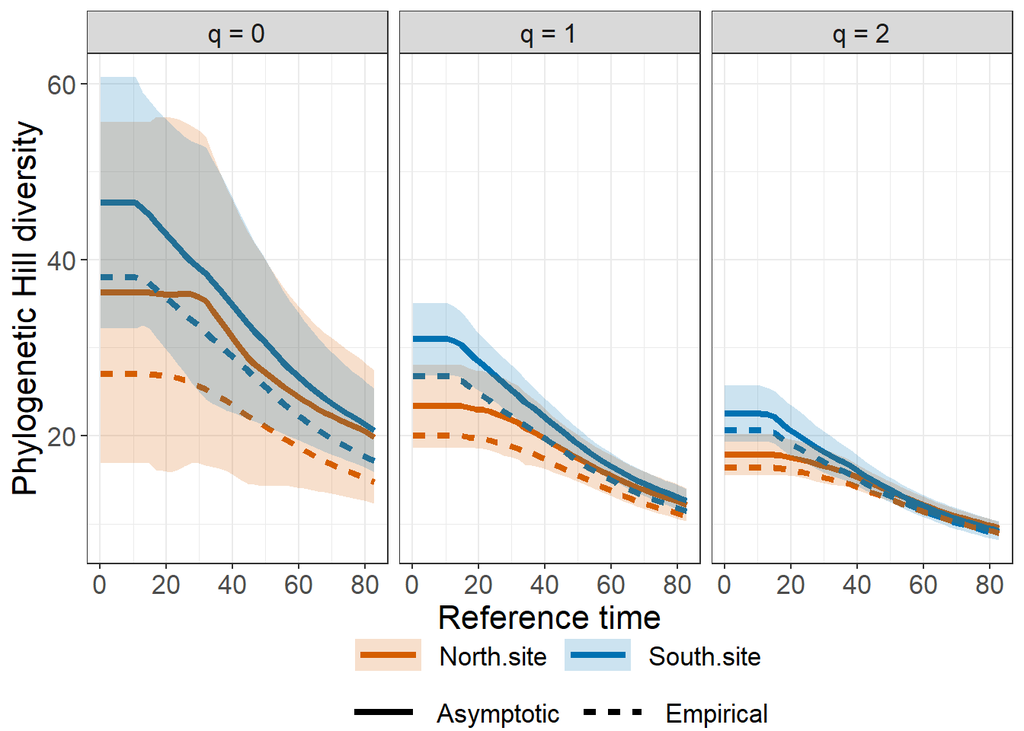

```r
# time curves, separating by "Order.q"
data(data.inc)
data <- data.inc$data
tree <- data.inc$tree
nT <- data.inc$nT
out2 <- AO3D(data, diversity = 'PD', q = c(0, 1, 2), datatype = "incidence_raw", nT = nT, nboot = 5, method = c("Asymptotic", "Observed"), PDtree = tree, PDreftime = seq(0.1, 82.8575, length.out = 40))
ggAO3D(out2, profile = "time")
```

The argument `profile = "tau"` in `ggAO3D` function creates a separate plot for each order.q. Therefore the different assemblages will seperated by different colours as shown below:

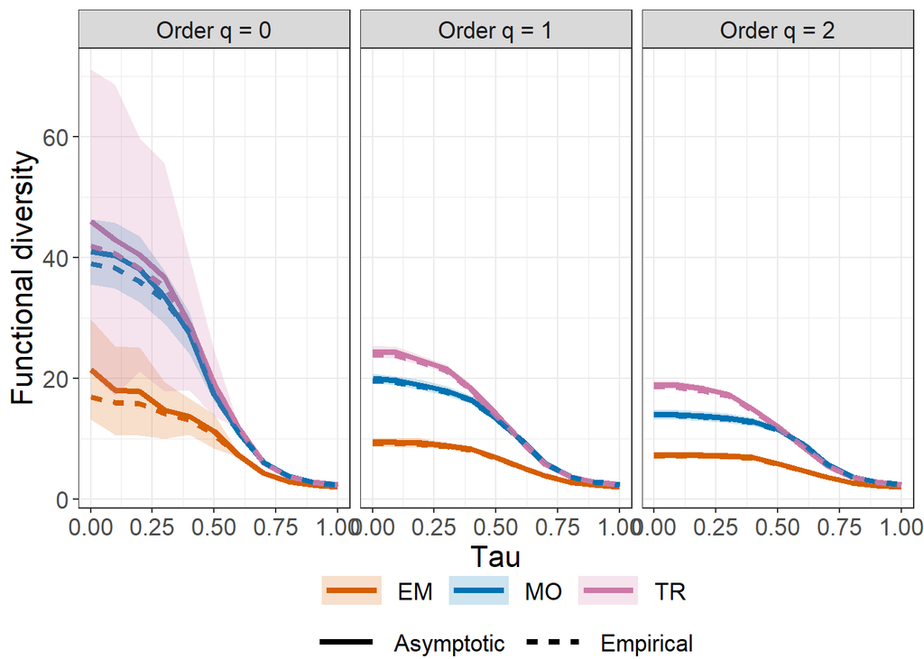

```r
# tau curves, separating by "Order.q"
data <- dunes$data
distM <-  dunes$dist
out3 <- AO3D(data, diversity = 'FD', q = c(0, 1, 2), datatype = "abundance", nboot = 5, method = c("Asymptotic", "Observed"), FDtau = seq(0, 1, 0.1), FDdistM = distM, FDtype = 'tau_values')
ggAO3D(out3, profile = "tau")
```